# Perceptions About Electricity in Afghanistan: Findings From SAP

Prepared by: Masood Sadat

May 2, 2018

### About

This report is prepared following a requrest by *Peter Stevenson* from Mercy Corps–Afghanistan.

### Awareness of Government Supplied Electricity Projects

> **Key Question**: **x11as.** I am going to read a list of projects that may or may not have been implemented in your area. Please tell me if there has been this type of project in your area in the last 12 months… Government supplied electricity

Since 2014, the Survey asks its respondents whether they are aware of implementation of a government supplied electricity project in their local area. Very few (16.5%) reported awareness of electricity supply projects in their local areas. In Kabul province, the awareness of new electricity supply projects have been decreasing in Kabul city, while in the rural areas this is increasing. The following graph shows the reported awareness in Kabul province disaggregated by urban and rural populations.

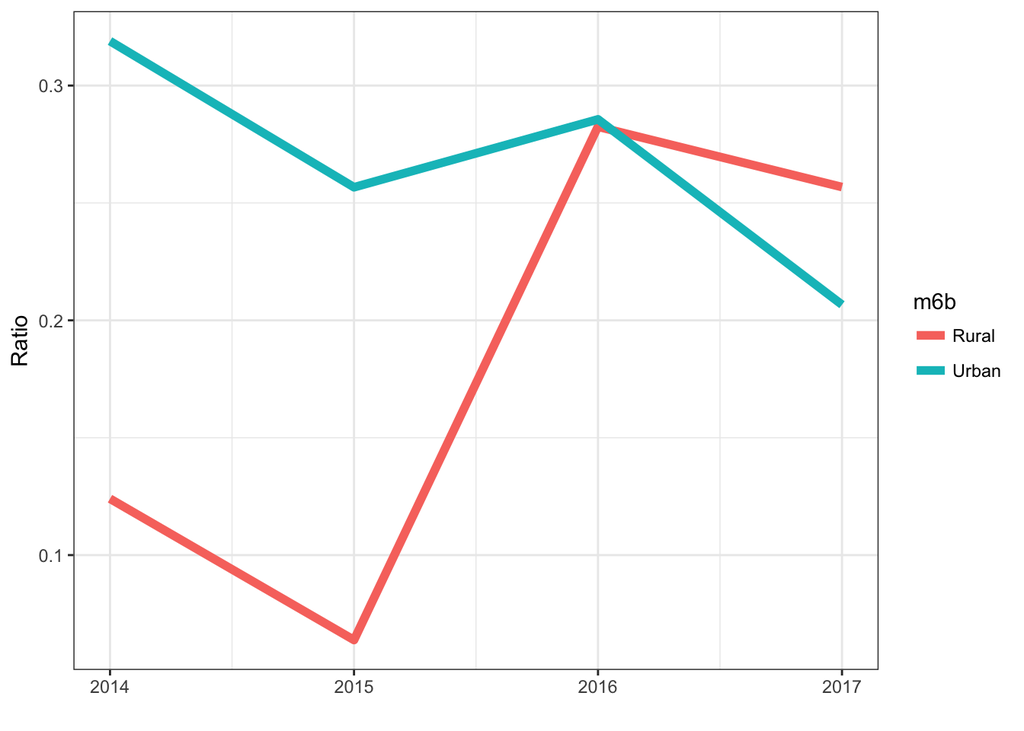

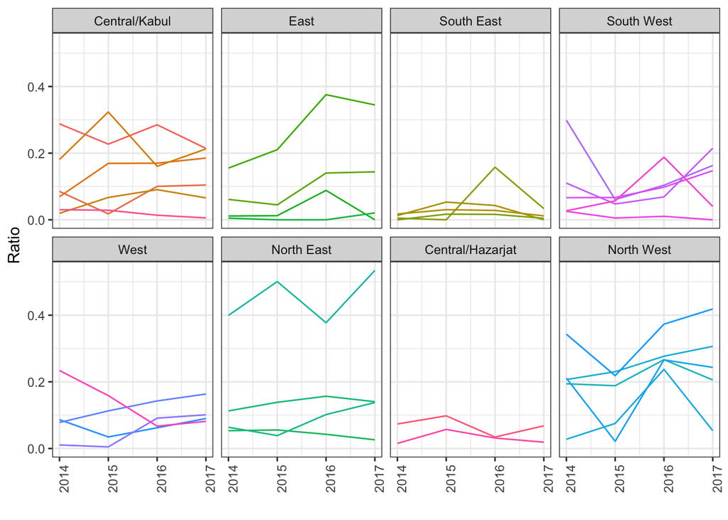

### Perception of Improved Electricity Supply

> **Key Question**: **x14g.** Compared to two years ago, would you say that situation for your household has gotten better, remained the same or gotten worse with respect to the following?… Electric supply

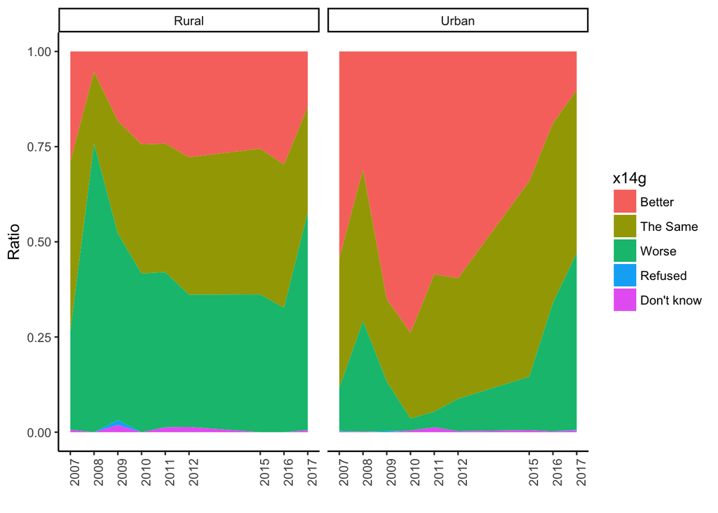